# Comparison of CPU and memory resource use of each algorithm

It is difficult to directly compare the resource requirements of each algorithm because each one involves different parameters and often requires selecting specific programs for tasks like read alignment or inferring SNP distances from multiple sequence alignments. To enhance comparability, we consistently opted for the same algorithms used in the TRACS pipeline whenever feasible.

To assess speed and memory requirements, we ran each algorithm on all 90 simulations of metagenomic sequencing data involving a pair of samples, where one genome had been transmitted. Some algorithms, like StrainGE, do not scale as efficiently when analysing multiple species simultaneously, which means that this algorithm is likely to take longer with larger datasets involving the transmission of multiple species.

Overall, these results offer a general indication of each algorithm’s performance. However, the exact differences in speed and memory usage will vary depending on the characteristics of each specific dataset.

## Run each method

The initial runs were completed as outline in the `simulations_metagenomic_mixture.Rmd` document. The following commands were used to run only the comparison steps of each algorithm.

### Run comparison steps only

#### InStrain

```
mkdir -p instrain_comparisons
mkdir -p instrain_time_logs

for parent_dir in sim_*/instrain_sim_d5*; do
  # Define the full paths for sampleA and sampleB
  sampleA_path=$(echo "${parent_dir}"/sampleA*)
  sampleB_path=$(echo "${parent_dir}"/sampleB*)

  # Check if both sampleA and sampleB directories exist within the parent directory.
  if [ -d "$sampleA_path" ] && [ -d "$sampleB_path" ]; then
    # Create a unique name for the output files based on the parent directory path.
    # This replaces slashes with underscores to create a valid filename.
    # e.g., "sim_99/instrain_sim_d5_..." becomes "sim_99_instrain_sim_d5_..."
    output_prefix=$(echo "$parent_dir" | tr '/' '_')

    # Define the output file paths for the comparison results and the time log.
    output_tsv="instrain_comparisons/${output_prefix}_compare.tsv"
    time_log="instrain_time_logs/${output_prefix}_time_log.txt"

    # Construct and print the full command to be executed.
    # Each command is printed on a new line.
    echo "/usr/bin/time -v -o ${time_log} inStrain compare -i ${sampleA_path} ${sampleB_path} -o ${output_tsv} --min_cov 2 -p 1" >> timing_intrain_compare_cmds.txt
  fi
done

parallel --joblog timing_intrain_compare_joblog.txt --progress -j 90 < timing_intrain_compare_cmds.txt
```

#### StrainGE

```
mkdir -p strainge_comparisons
mkdir -p strainge_time_logs

rm timing_strainge_compare_cmds.txt
for parent_dir in sim_*/strainge_sim_d5*; do
  # Define the full paths for sampleA and sampleB
  sampleA_path="${parent_dir}/sampleA/sampleA.hdf5"
  sampleB_path="${parent_dir}/sampleB/sampleB.hdf5"
  echo $sampleA_path
  echo $sampleB_path

  # Check if both sampleA and sampleB directories exist within the parent directory.
  if [ "$sampleA_path" ] && [ "$sampleB_path" ]; then
    # Create a unique name for the output files based on the parent directory path.
    # This replaces slashes with underscores to create a valid filename.
    # e.g., "sim_99/instrain_sim_d5_..." becomes "sim_99_instrain_sim_d5_..."
    output_prefix=$(echo "$parent_dir" | tr '/' '_')

    # Define the output file paths for the comparison results and the time log.
    output_tsv="strainge_comparisons/${output_prefix}_compare.tsv"
    time_log="strainge_time_logs/${output_prefix}_time_log.txt"

    # Construct and print the full command to be executed.
    # Each command is printed on a new line.
    echo "/usr/bin/time -v -o ${time_log} straingr compare -o ${output_tsv} ${sampleA_path} ${sampleB_path}" >> timing_strainge_compare_cmds.txt
  fi
done

parallel --joblog timing_strainge_compare_joblog.txt --progress -j 90 < timing_strainge_compare_cmds.txt
```

#### TRACS

```
mkdir -p tracs_comparisons
mkdir -p tracs_time_logs

rm timing_tracs_compare_cmds.txt
rm timing_tracs_combine_cmds.txt
for parent_dir in sim_*/tracs_filt_reduced_db_sim_d5*; do
  # Define the full paths for sampleA and sampleB
  sampleA_path=$(echo "${parent_dir}"/sampleA*)
  sampleB_path=$(echo "${parent_dir}"/sampleB*)

  # Check if both sampleA and sampleB directories exist within the parent directory.
  if [ -d "$sampleA_path" ] && [ -d "$sampleB_path" ]; then
    # Create a unique name for the output files based on the parent directory path.
    # This replaces slashes with underscores to create a valid filename.
    # e.g., "sim_99/instrain_sim_d5_..." becomes "sim_99_instrain_sim_d5_..."
    output_prefix=$(echo "$parent_dir" | tr '/' '_')

    # Define the output file paths for the comparison results and the time log.
    output_dir="tracs_comparisons/${output_prefix}_combined"
    output_tsv="tracs_comparisons/${output_prefix}_compare.tsv"
    time_log="tracs_time_logs/${output_prefix}_time_log.txt"

    # Construct and print the full command to be executed.
    # Each command is printed on a new line.
    echo "/usr/bin/time -v -o ${time_log} tracs combine -i ${sampleA_path} ${sampleB_path} -o ${output_dir}" >> timing_tracs_combine_cmds.txt
    echo "/usr/bin/time -v -o ${time_log} tracs distance --msa ${output_dir}/*.fasta.gz -o ${output_tsv} --filter" >> timing_tracs_compare_cmds.txt
  fi
done

parallel --joblog timing_tracs_combine_joblog.txt --progress -j 90 < timing_tracs_combine_cmds.txt
parallel --joblog timing_tracs_compare_joblog.txt --progress -j 90 < timing_tracs_compare_cmds.txt
```

#### Collect run time summaries

```
for file in *joblog.txt; do awk 'NR > 1 { commands++; if ($7 == 0) success++; runtime += $4 } END { if (commands == 90 && success == 90) { d=int(runtime/86400); h=int(runtime%86400/3600); m=int(runtime%3600/60); printf "%s: %d days, %d hours, %d minutes\n", FILENAME, d, h, m } }' "$file"; done
```

## Generate summary plots

```r
library(tidyverse)
library(ggthemes)
library(patchwork)
library(dplyr)
```

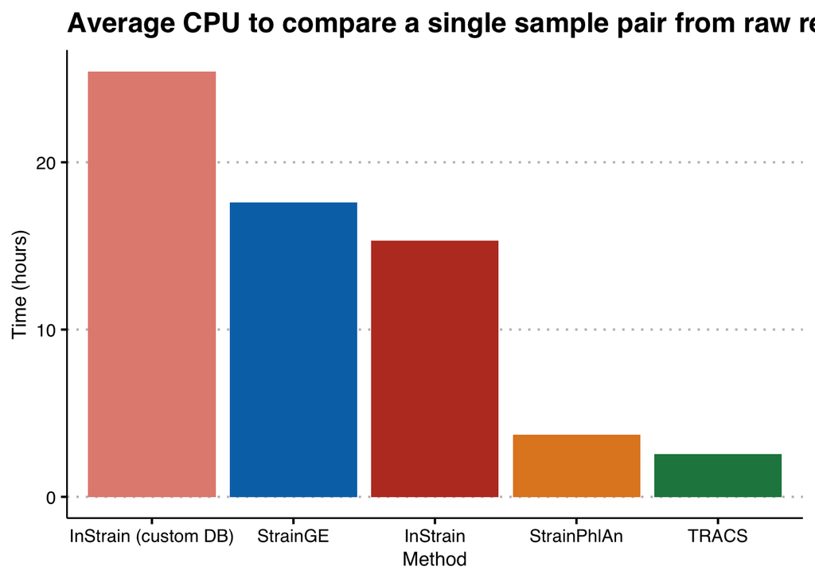

```r
timing_data_90_pairs <- tibble(
method=c("InStrain", "InStrain (custom DB)", "StrainGE", "StrainPhlAn", "TRACS"),
time = c(4961315, 4961315 + 3280652, 5701871, 1206871, 823445)
)

lvls <- timing_data_90_pairs$method[order(-timing_data_90_pairs$time)]

timing_data_90_pairs$method <- factor(timing_data_90_pairs$method,
                                      levels=lvls)

gg1 <- ggplot(timing_data_90_pairs, aes(x=method, y=time/3600/90, fill=method)) +
  geom_bar(stat="identity") +
  labs(x="Method", y="Time (hours)", title="Average CPU to compare a single sample pair from raw reads") +
  theme_clean(base_size = 15) +
  theme(plot.background = element_blank()) +
  theme(legend.position = "none") +
  scale_fill_manual(values=c("TRACS"="#20854EFF", "InStrain"="#BC3C29FF", "InStrain (custom DB)"="#E38D81",
                                       "StrainPhlAn"="#E18727FF", "StrainGE"="#0072B5FF"))
gg1
```

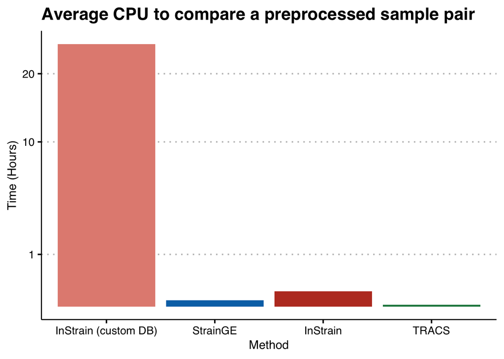

```r
# Note we are substituting the TRACS time in for StrainPhlAn as the algorithm outputs a MSA which can be used with any subsequent distance algorithm.
timing_data_compare <- tibble(
method=c("InStrain", "InStrain (custom DB)", "StrainGE", "StrainPhlAn", "TRACS"),
time = c(28052, 4961315 + 3280652, 4558, 384, 384)
)


timing_data_compare$method <- factor(timing_data_compare$method,
                                      levels=lvls)

gg2 <- ggplot(timing_data_compare |> filter(method!="StrainPhlAn"), aes(x=method, y=time/90/3600, fill=method)) +
  geom_bar(stat="identity") +
  #alternative to scale_y_log10() to avoid log scale
  # scale_y_continuous(trans = scales::pseudo_log_trans(base = 10)) +
  scale_y_sqrt(breaks=c(1, 10, 20)) +
  labs(x="Method", y="Time (Hours)", title="Average CPU to compare a preprocessed sample pair") +
  theme_clean(base_size = 15) +
  theme(plot.background = element_blank()) +
  theme(legend.position = "none") +
  scale_fill_manual(values=c("TRACS"="#20854EFF", "InStrain"="#BC3C29FF", "InStrain (custom DB)"="#E38D81",
                                       "StrainPhlAn"="#E18727FF", "StrainGE"="#0072B5FF"))
gg2
```

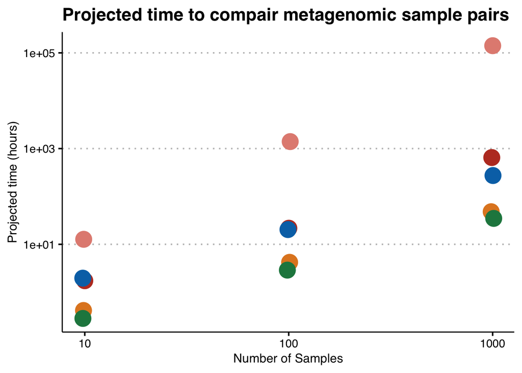

```r
time_projection <- function(n, total_pair_run_time, comparison_time){
  return(n * (total_pair_run_time - comparison_time)/90 + choose(n, 2) * comparison_time/90)
}


projected_times <- map_dfr(c(10, 100, 1000), ~{
  tibble(
    method = timing_data_90_pairs$method,
    projected_time = time_projection(.x, timing_data_90_pairs$time, timing_data_compare$time),
    n_pairs = .x
  )
})


gg3 <- ggplot(projected_times, aes(x=n_pairs, y=projected_time/90/3600, colour=method)) +
  geom_jitter(size=7, height = 0, width=0.01) +
  scale_y_log10() +
  scale_x_log10() +
  labs(x="Number of Samples", y="Projected time (hours)", title="Projected time to compair metagenomic sample pairs") +
  theme_clean(base_size = 15) +
  theme(plot.background = element_blank()) +
  theme(legend.position = "none") +
  scale_colour_manual(values=c("TRACS"="#20854EFF", "InStrain"="#BC3C29FF", "InStrain (custom DB)"="#E38D81",
                                       "StrainPhlAn"="#E18727FF", "StrainGE"="#0072B5FF"))
gg3
```

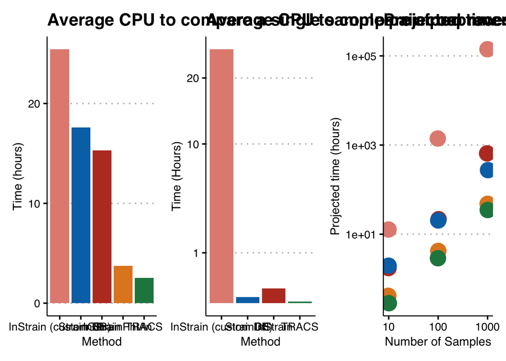

```r
gg1 + gg2 + gg3
```

### Memory Consumption

To provide an estimate of memory consumption, we ran each algorithm on a single pair of samples from the 90 simulations. The following commands were used to run each algorithm on a single pair of samples, and the memory usage was recorded using the `time` command.

#### TRACS

[output not shown]

#### InStrain

[output not shown]

#### StrainPlAn

[output not shown]

#### StrainGE

[output not shown]

#### Summary plots

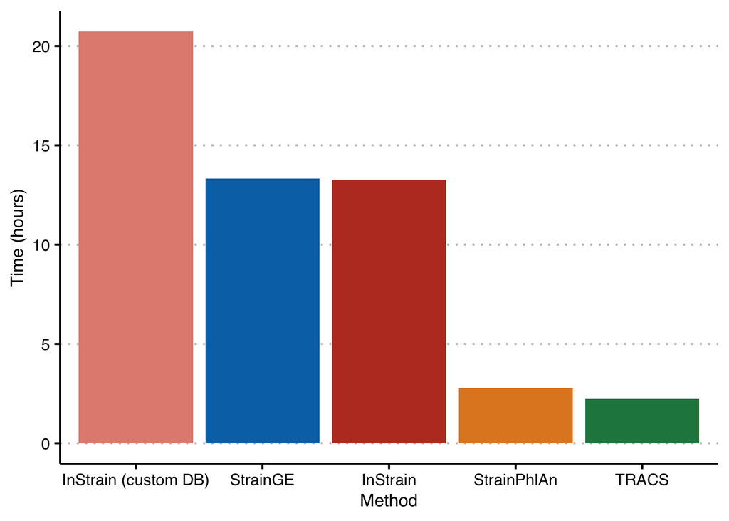

```r
res <- map_dfr(Sys.glob("./data/memory/*.txt"), ~{
  lines <- str_trim(read_lines(.x))
  tibble(
    method = gsub(".*/", "", gsub("_time.*", "", .x)),
    memory = as.numeric(str_split(lines[grepl("Maximum resident set size", lines)], ": ")[[1]][[2]])/(1024**2),
    cpu = sum(as.numeric(str_split_fixed(lines[grepl("^[US].*time*", lines)], ": ", 2)[,2]))/60/60
  )
})

res$memory[res$method == "metaspades_full_pair"] <- res$memory[res$method == "metaspades_full_pair"] + res$memory[res$method == "instrain_full_pair"]
res$cpu[res$method == "metaspades_full_pair"] <- res$cpu[res$method == "metaspades_full_pair"] + res$cpu[res$method == "instrain_full_pair"]

res$Method <- recode(res$method,
                     "instrain_compare_pair" = "InStrain",
                     "instrain_full_pair" = "InStrain",
                     "strainphlan_full_pair" = "StrainPhlAn",
                     "strainge_compare_pair" = "StrainGE",
                     "strainge_full_pair" = "StrainGE",
                     "tracs_full_pair" ="TRACS",
                     "tracs_compare_pair" ="TRACS",
                     "metaspades_full_pair" = "InStrain (custom DB)")



res$compare <- ifelse(grepl("compare", res$method), "Compare", "Full")

# widen
pdf <- res %>%
  filter(compare=='Full')

pdf$Method <- factor(pdf$Method, levels=lvls)

ggplot(pdf, aes(x=Method, y=cpu, fill=Method)) +
  geom_bar(stat="identity") +
  labs(x="Method", y="Time (hours)") +
  theme_clean(base_size = 15) +
  theme(plot.background = element_blank()) +
  theme(legend.position = "none") +
  scale_fill_manual(values=c("TRACS"="#20854EFF", "InStrain"="#BC3C29FF", "InStrain (custom DB)"="#E38D81",
                                       "StrainPhlAn"="#E18727FF", "StrainGE"="#0072B5FF"))
```

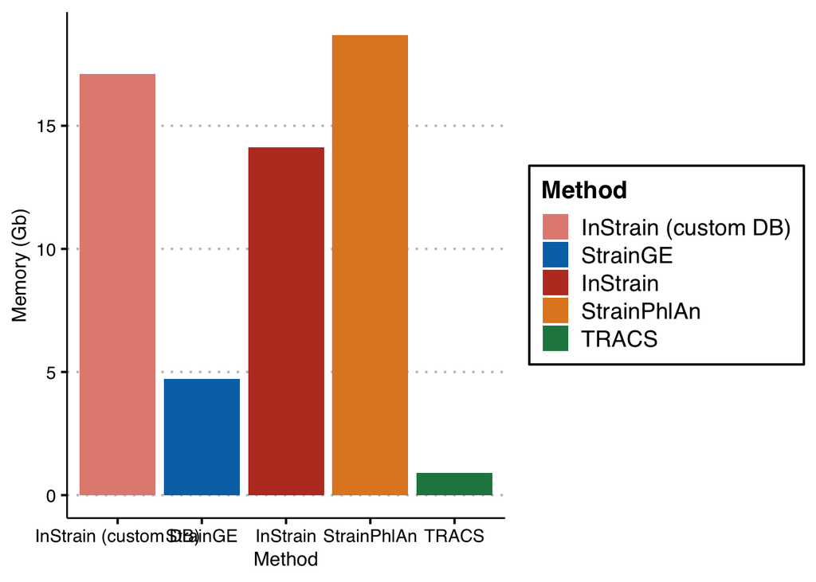

```r
gg4 <- ggplot(pdf, aes(x=Method, y=memory, fill=Method)) +
  geom_bar(stat="identity") +
  labs(x="Method", y="Memory (Gb)") +
  theme_clean(base_size = 15) +
  theme(plot.background = element_blank()) +
  # theme(legend.position = "none") +
  scale_fill_manual(values=c("TRACS"="#20854EFF", "InStrain"="#BC3C29FF", "InStrain (custom DB)"="#E38D81",
                                       "StrainPhlAn"="#E18727FF", "StrainGE"="#0072B5FF"))
gg4
```

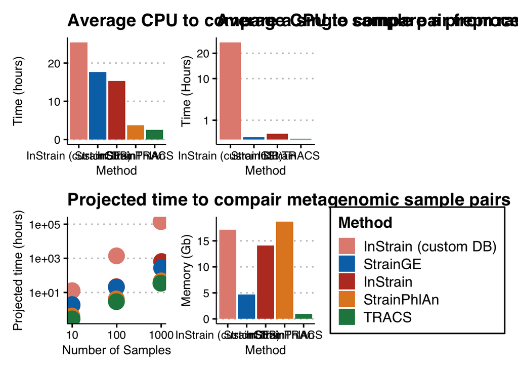

```r
gg1 + gg2 + gg3 + gg4 + patchwork::plot_layout(nrow = 2, ncol = 2)
```

```r
# ggsave("./figures/resources.png", width = 12, height = 10)
# ggsave("./figures/resources.pdf", width = 12, height = 10)
```